# Linear regression Model for Coffee Sales at Vending Machines in 2024

Christopher Kent Leal

2024-07-18

# Introduction

This project leverages the `Coffee_Vendor_Machine_Sales` to build a linear regression model to predict the cost of the average of coffee drinks available for the second half of 2024 using data accumulated for the first half of the year. This regression model is focuses in Python and will be automatically executed and shown below.

## Understanding The Dataset:

In order to get to building a linear regression model, we first need to better understand the dataset itself and figure out a way to leverage the data to accomplish a goal by choosing the variables that are essential to perform the calculation. In this instance, I decided to leverage the `Coffee_Vendor_Machine_Sales` dataset in order to calculate the amount of money spent over time for coffee drinks from vending machines. A simple way to understand the data it to simply show in in various ways using modules like `head()`, `tail()`, `summary()`, `describe()`, etc. Here, I use the first in order to show 9 rows of data from the dataset.:

```r
# Import dataset from the data/ folder
coffee_data <- read.csv("C:\\Users\\Christopher K. Leal\\Documents\\Cyber Security Documentation\\Cyber Security\\GitHub Projects\\AI-Projects\\Pytorch-Tests\\data\\Coffee_Vendor_Machine_Sales.csv")
head_data <- head(coffee_data, 9)
print(head_data)
```

```
##         date                datetime cash_type                card money
## 1 2024-03-01 2024-03-01 10:15:50.520      card ANON-0000-0000-0001  38.7
## 2 2024-03-01 2024-03-01 12:19:22.539      card ANON-0000-0000-0002  38.7
## 3 2024-03-01 2024-03-01 12:20:18.089      card ANON-0000-0000-0002  38.7
## 4 2024-03-01 2024-03-01 13:46:33.006      card ANON-0000-0000-0003  28.9
## 5 2024-03-01 2024-03-01 13:48:14.626      card ANON-0000-0000-0004  38.7
## 6 2024-03-01 2024-03-01 15:39:47.726      card ANON-0000-0000-0005  33.8
## 7 2024-03-01 2024-03-01 16:19:02.756      card ANON-0000-0000-0006  38.7
## 8 2024-03-01 2024-03-01 18:39:03.580      card ANON-0000-0000-0007  33.8
## 9 2024-03-01 2024-03-01 19:22:01.762      card ANON-0000-0000-0008  38.7
##           coffee_name
## 1               Latte
## 2       Hot Chocolate
## 3       Hot Chocolate
## 4           Americano
## 5               Latte
## 6 Americano with Milk
## 7       Hot Chocolate
## 8 Americano with Milk
## 9               Cocoa
```

# Interactive figures with plotly

The following code block shows what the dataset looks like by default when assigning both variables `money` and `date` to `X` and `Y` respectively and assigning color values based on the `coffee_name` categorical data from the dataset as well.:

```r
# If plotly is installed run:
p <- plotly::plot_ly(data = coffee_data, x = ~money, y = ~date, color = ~coffee_name)
plotly::add_markers(p)
```

[interactive chart not shown]

Interactive htmlwidget ‘plotly’ to show the raw dataset

# The Linear Regression ML model:

## Predicting Coffee Prices:

After spending time conducting data exploration, if the data is already formatted/cleansed, then we can get right to the meat and potatoes of the objective and begin to construct the regression model itself. The following code chunk imports and executes the regression model designed for the `Coffee_Vendor_Machine_Sales` dataset to visualize the output in this neatly organized R Markdown document.

*Note: This document is not a step-by-step tutorial, but is rather a quick example to showcase how you can create a beautiful R Markdown document while also combining Python, R and executing an ML linear regression model while also allowing for transparency for others to replicate and leverage it.*

```
## coefficients:  [-0.00323365]
## intercept:  2423.903371748314
## Mean absolute error: 4.06
```

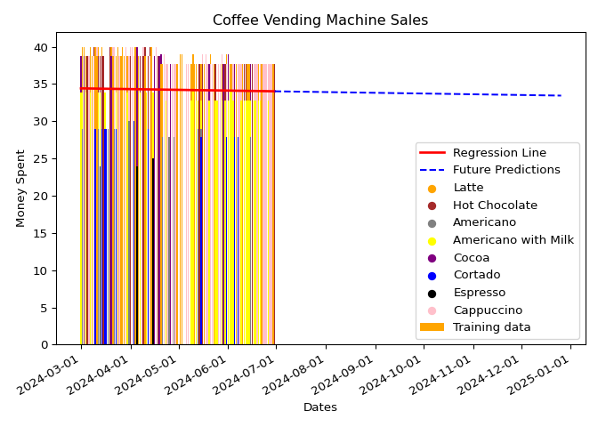

```python
from sklearn import linear_model
import matplotlib.pyplot as plt
import pandas as pd
import pylab as pl
import numpy as np
import datetime as dt
import matplotlib.dates as mdates

coffee_data = r"C:\Users\Christopher K. Leal\Documents\Cyber Security Documentation\Cyber Security\GitHub Projects\AI-Projects\Pytorch-Tests\data\Coffee_Vendor_Machine_Sales.csv"
df = pd.read_csv(coffee_data)

df['date'] = pd.to_datetime(df['date'], errors='coerce')  # Ensure 'date' is in datetime format
df['date_ordinal'] = df['date'].map(dt.datetime.toordinal)  # Drop any rows where 'date' conversion failed

# Drop rows with NaT in 'date'
df = df.dropna(subset=['date_ordinal'])

# Prepare the feature and target variables
X = df[['date_ordinal']]  # Feature variable as 2D array
y = df['money']  # Target variable

def regression_model():
    # Split the data into training and testing sets
    msk = np.random.rand(len(df)) < 0.8

    X_train = X[msk]
    X_test = X[~msk]
    y_train = y[msk]
    y_test = y[~msk]

    colors = {'Latte':'orange', 'Hot Chocolate':'brown', 'Americano': 'grey', 'Americano with Milk':'yellow', 'Cocoa':'purple', 'Cortado':'blue', 'Espresso':'black', 'Cappuccino':'pink'}
    df['color'] = df['coffee_name'].map(colors)

      # Apply colors to training data only for the scatter plot
    X_train_color = df.loc[msk, 'color']
    coffee_names = df['coffee_name'].unique()  # Get unique coffee names

    regr = linear_model.LinearRegression()
    regr.fit(X_train, y_train)

    # Print the coefficients:
    print('coefficients: ', regr.coef_)
    print('intercept: ', regr.intercept_)

        # Convert ordinal dates back to datetime for plotting
    X_train_dates = [dt.datetime.fromordinal(int(d)) for d in X_train['date_ordinal']]
    X_test_dates = [dt.datetime.fromordinal(int(d)) for d in X_test['date_ordinal']]

    plt.bar(X_train_dates, y_train, color=X_train_color, label='Training data')
    plt.plot(X_test_dates, regr.predict(X_test), color='red', linewidth=2, label='Regression Line')

    # Extend the date range for future predictions
    future_dates = pd.date_range(start=df['date'].max(), periods=180).to_pydatetime().tolist()
    future_ordinal_dates = [d.toordinal() for d in future_dates]
    future_predictions = regr.predict(pd.DataFrame(future_ordinal_dates, columns=['date_ordinal']))

    # Plot future predictions
    plt.plot(future_dates, future_predictions, color='blue', linestyle='--', label='Future Predictions')

    plt.xlabel("Dates")
    plt.ylabel("Money Spent")
    plt.title("Coffee Vending Machine Sales")

    for coffee, color in colors.items():
        plt.scatter([], [], color=color, label=coffee)

    plt.legend()

        # Format the x-axis to show dates
    plt.gca().xaxis.set_major_formatter(mdates.DateFormatter('%Y-%m-%d'))
    plt.gca().xaxis.set_major_locator(mdates.MonthLocator())
    plt.gcf().autofmt_xdate()  # Rotate date labels to fit

            # Adjust layout
    plt.tight_layout()

    plt.show()

    prediction = regr.predict(X_test)
    print("Mean absolute error: %.2f" % np.mean(np.absolute(prediction - y_test)))

regression_model()
```

# Conclusion:

When looking at the coefficients and intercept, we understand that these are the two values that are used to plot our line. Finally, the mean absolute error averages the difference between the predicted values and the actual values. The MAE in this case typically sits at around 3.7 to 4.2. While high, this is as exercise designed to understand the workings of regression models, R markdown and Python programming and how once may go about presenting the data in a neat and organized manner with reproducibility for other to replicate, analyze and improve.